# Gasto global em saúde, 2000 a 2023: quem paga a conta e onde o Brasil se situa

Ana Gabriella Prestes da Silva

Ana Teresa Throniecke Alves

Maria Eduarda Neves Galvão

13/11/2026

# 1 Introdução

A saúde é, ao mesmo tempo, um direito e um dos setores que mais consomem recursos nas economias modernas. A forma como os países financiam seus sistemas de saúde, isto é, quanto vem do orçamento público, quanto é pago pelas famílias e quanto chega de fontes externas, influencia diretamente o acesso aos serviços e a proteção financeira da população. Quando uma parcela grande do gasto recai sobre o bolso das famílias no momento do uso do serviço, aumenta o risco de que uma doença se transforme em empobrecimento (Xu et al., 2003). Por isso, a Organização Mundial da Saúde defende que os sistemas dependam de mecanismos de pré-pagamento, como impostos e seguros, e não de pagamentos diretos (Organização Mundial da Saúde, 2010).

O caso brasileiro é particularmente interessante. A Constituição de 1988 estabeleceu a saúde como direito de todos e dever do Estado (Brasil, 1988), o que deu origem ao Sistema Único de Saúde (SUS), um sistema público e universal (Paim et al., 2011). Ao mesmo tempo, o país mantém um grande setor privado, de modo que o financiamento da saúde no Brasil é misto. Isso levanta uma pergunta natural: como esse arranjo se compara ao de outros países?

Este trabalho analisa o *Global Health Expenditure Database* (GHED), da Organização Mundial da Saúde (Organização Mundial da Saúde, 2025), que reúne o gasto em saúde de 195 países entre 2000 e 2023. O problema central é descrever como o gasto em saúde está distribuído e como ele evoluiu, com atenção à origem dos recursos e à posição do Brasil. Os objetivos específicos são: (a) descrever a evolução do gasto mundial em saúde e a concentração desse gasto entre os países; (b) caracterizar quem financia a saúde (governo, setor privado e exterior) e qual o peso do gasto direto das famílias; (c) examinar a relação entre o tamanho do gasto total e a forma de financiamento; (d) avaliar o efeito da pandemia de COVID-19 sobre o gasto entre 2019 e 2020; e (e) situar o Brasil em relação ao conjunto dos países.

O texto está organizado em quatro partes. A Seção 2 descreve os dados e os métodos, a Seção 3 apresenta e discute os resultados, a Seção 4 discute as limitações e a Seção 5 reúne as conclusões.

# 2 Materiais e métodos

## 2.1 Dados

Os dados foram obtidos pelo projeto TidyTuesday (semana 16 de 2026) (R4DS Online Learning Community, 2026), que disponibiliza em formato aberto informações da base GHED (Organização Mundial da Saúde, 2025). O conjunto é formado por três tabelas em formato longo, nas quais cada linha traz um país, um ano, um indicador e um valor:

- **fonte do gasto** (`health_spending`): gasto corrente em saúde e sua divisão entre governo, setor privado e fontes externas;
- **esquema de financiamento** (`financing_schemes`): divisão do gasto entre governo, seguros voluntários, gasto direto das famílias, exterior e não especificado;
- **finalidade do gasto** (`spending_purpose`): divisão do gasto entre tipos de serviço, como atenção curativa, reabilitação, serviços preventivos e bens médicos.

Cada indicador aparece em duas versões: como porcentagem do gasto corrente em saúde e em dólares americanos constantes de 2023, o que permite comparar valores entre anos sem o efeito da inflação. As duas primeiras tabelas cobrem 195 países entre 2000 e 2023. A tabela de finalidade é mais restrita: cobre os anos de 2016 a 2023 e um número menor de países, que diminui ao longo do período (123 países em 2018 e 65 em 2023).

## 2.2 Pré-processamento

As três tabelas foram convertidas para o formato largo, com uma linha por país e ano, e reunidas em um único painel de 4588 linhas. As decisões de tratamento foram as seguintes:

- percentuais ausentes foram tratados como 0%, pois, em cada tabela, as partes somam aproximadamente 100% e a ausência indica que a categoria não se aplica ao país naquele ano;
- os valores em dólares ausentes foram mantidos como dados faltantes. É o caso de Cuba, que não tem valores em dólares e, por isso, não aparece nas análises que usam valores monetários;
- os nomes dos países foram traduzidos para o português a partir do código ISO de três letras, usando o pacote `countrycode`, que serviu apenas para essa tradução;
- as comparações entre anos usam sempre dólares constantes de 2023;
- as três tabelas foram unidas pela tabela de fonte, por junção à esquerda, usando como chaves o país, o código ISO e o ano. Assim, a finalidade do gasto fica como dado faltante nos anos e países em que essa tabela não tem informação;
- a categoria “governo” tem dois sentidos na base. Na origem do gasto, ela é o gasto do governo geral (GGHED). Nos esquemas de financiamento, ela inclui também os esquemas de contribuição obrigatória, e por isso pode ser maior;
- como verificação, conferiu-se que as partes de cada tabela somam cerca de 100%: entre 99,6% e 100,3% na origem do gasto e entre 99,6% e 100,4% nos esquemas, diferenças atribuídas a arredondamento.

## 2.3 Métodos estatísticos

A análise combina estatística descritiva, gráficos e dois testes não paramétricos. Como o gasto total em saúde é fortemente assimétrico, com poucos países concentrando a maior parte do valor, as comparações usam a mediana em vez da média, e os gráficos de gasto total usam escala logarítmica quando os valores variam em várias ordens de grandeza.

Para medir a associação entre duas variáveis foi usada a **correlação de Spearman** (Spearman, 1904), que equivale à correlação de Pearson aplicada aos postos das observações. Ela não exige normalidade nem relação linear, apenas monotonicidade, o que a torna adequada a dados assimétricos. Também foi ajustada uma reta de regressão linear, usada apenas como resumo visual da tendência nos gráficos de dispersão.

Para avaliar o efeito da pandemia, calculou-se a variação percentual do gasto de cada país entre 2019 e 2020:

$$\Delta_i = \left(\frac{G_{i,2020}}{G_{i,2019}} - 1\right) \times 100,$$

em que $G_{i,t}$ é o gasto total do país $i$ no ano $t$. Para testar se o gasto mudou de forma sistemática, foi usado o **teste de Wilcoxon pareado** (Wilcoxon, 1945), que compara as duas medidas de cada país e não exige normalidade das diferenças. O pareamento é necessário porque os dois valores se referem ao mesmo país. Adotou-se nível de significância de 5%.

## 2.4 Ferramentas computacionais e reprodutibilidade

Toda a análise foi feita na linguagem R (R Core Team, 2025), versão 4.5.2. Os dados foram obtidos diretamente da internet com o pacote `tidytuesdayR`. A manipulação dos dados (seleção, filtros, criação de variáveis, junções e mudança de formato) usou `dplyr` (versão 1.2.1) e `tidyr` (versão 1.3.2), do conjunto `tidyverse` (Wickham et al., 2019). Os gráficos foram feitos com `ggplot2` (versão 4.0.3), com o pacote `scales` para os formatos de número, e as tabelas com `knitr`. O pacote `countrycode` foi usado apenas para traduzir os nomes dos países.

O fluxo de trabalho foi organizado para ser reproduzível. Um único roteiro de preparação baixa os dados, faz o tratamento descrito na Seção 2.2 e grava o painel final em um arquivo. As cores e o tema dos gráficos ficam em um arquivo de configuração comum, e o código está versionado em um repositório no GitHub. O relatório foi escrito em R Markdown (Xie; Allaire; Grolemund, 2018), com os pacotes `rmarkdown` e `bookdown` para as referências cruzadas, e todos os números do texto são calculados pelo código no momento da geração do documento.

# 3 Resultados e discussão

## 3.1 Evolução e concentração do gasto mundial

O gasto mundial em saúde passou de US$ 4,7 trilhões em 2000 para US$ 10,6 trilhões em 2023, em valores constantes de 2023, um aumento de 126% (Figura 1). A trajetória é de crescimento contínuo, com um salto visível em 2020, quando o total passou de US$ 9,4 trilhões para US$ 10,1 trilhões, no primeiro ano da pandemia.

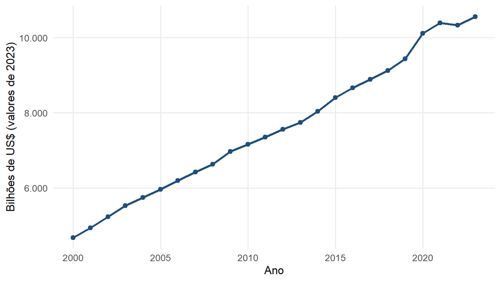

Figura 1: Gasto mundial em saúde, 2000 a 2023 (bilhões de US$ de 2023). Fonte: elaboração própria, com dados da OMS (GHED).

Esse gasto é muito concentrado. Em 2023, os Estados Unidos responderam sozinhos por 44% do total mundial, e os cinco maiores gastadores juntos por 67%, ou seja, cerca de dois terços de tudo o que o mundo gasta em saúde (Figura 2). O Brasil ocupava a 8ª posição em 2023, contra a 9ª em 2000. Seu gasto, no entanto, é pequeno diante do líder: o Brasil aparece na lista, mas com uma fração do valor dos Estados Unidos.

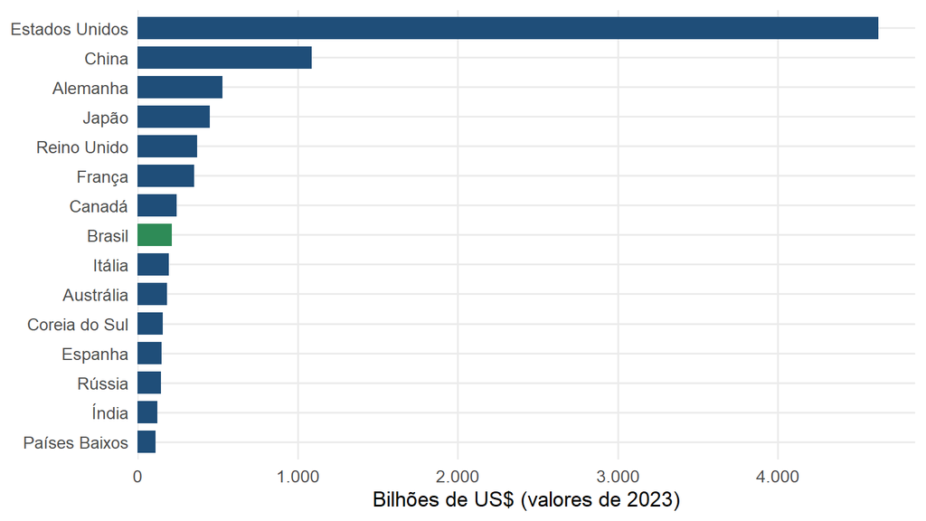

Figura 2: Os 15 países que mais gastam em saúde, 2023. O Brasil aparece em verde. Fonte: elaboração própria, com dados da OMS (GHED).

A participação do governo varia bastante mesmo entre os maiores gastadores: 54,0% nos Estados Unidos, 79,1% na Alemanha, 57,1% na China e 44,1% no Brasil. Gastar muito, portanto, não significa financiar a saúde da mesma forma, o que é discutido a seguir.

## 3.2 Quem paga a conta

Em 2023, a mediana mundial era de 56,8% do gasto financiado pelo governo e 34,1% pelo setor privado. Em 2000, a mediana do governo era de 50,7%. Houve, portanto, um aumento da participação pública ao longo do período, ainda que moderado.

A Tabela 1 resume a distribuição mundial desses indicadores e traz o valor do Brasil. O Brasil destoa dessa mediana. Em 2023, o governo financiou 44,1% do gasto em saúde no país e o setor privado 55,9%, uma inversão em relação à mediana mundial (Figura 3). A participação pública brasileira era de 41,6% em 2000 e variou pouco desde então: 40,7% em 2019 e 44,1% em 2023. Esse resultado chama atenção porque o Brasil tem um sistema público universal. O que os dados mostram é que o sistema público convive com um gasto privado de grande peso.

Tabela 1: Distribuição mundial dos indicadores de financiamento e valor do Brasil, 2023. Fonte: elaboração própria, com dados da OMS (GHED).

| Indicador | Mínimo | 1º quartil | Mediana | 3º quartil | Máximo | Brasil |
| --- | --- | --- | --- | --- | --- | --- |
| Governo (% do gasto) | 1,7 | 34,5 | 56,8 | 70,3 | 92,5 | 44,1 |
| Privado (% do gasto) | 0,1 | 23,0 | 34,1 | 51,2 | 83,9 | 55,9 |
| Seguro voluntário (%) | 0,0 | 4,5 | 8,4 | 14,5 | 68,5 | 29,6 |
| Bolso das famílias (%) | 0,0 | 14,2 | 27,5 | 43,6 | 80,5 | 26,2 |

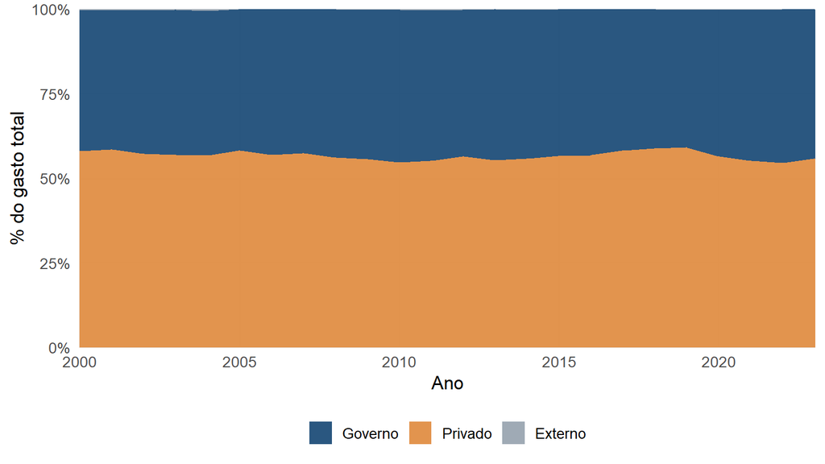

Figura 3: Origem do gasto em saúde no Brasil, 2000 a 2023 (% do gasto total). Fonte: elaboração própria, com dados da OMS (GHED).

Para entender o que compõe esse gasto privado, é preciso olhar os esquemas de financiamento (Figura 4). No Brasil, o gasto privado se divide entre o seguro voluntário, que respondeu por 29,6% do total em 2023 (a mediana mundial é de 8,4%), e o pagamento direto das famílias, de 26,2%. Em outras palavras, o setor privado brasileiro depende bastante dos planos de saúde, algo menos comum no mundo. Já Estados Unidos e Alemanha financiam mais de 80% do gasto por esquemas governamentais e de contribuição obrigatória (83,4% e 85,9%), com seguro voluntário abaixo de 6%; a China tem um perfil intermediário, com 57,1% de financiamento governamental e 32,2% de gasto direto.

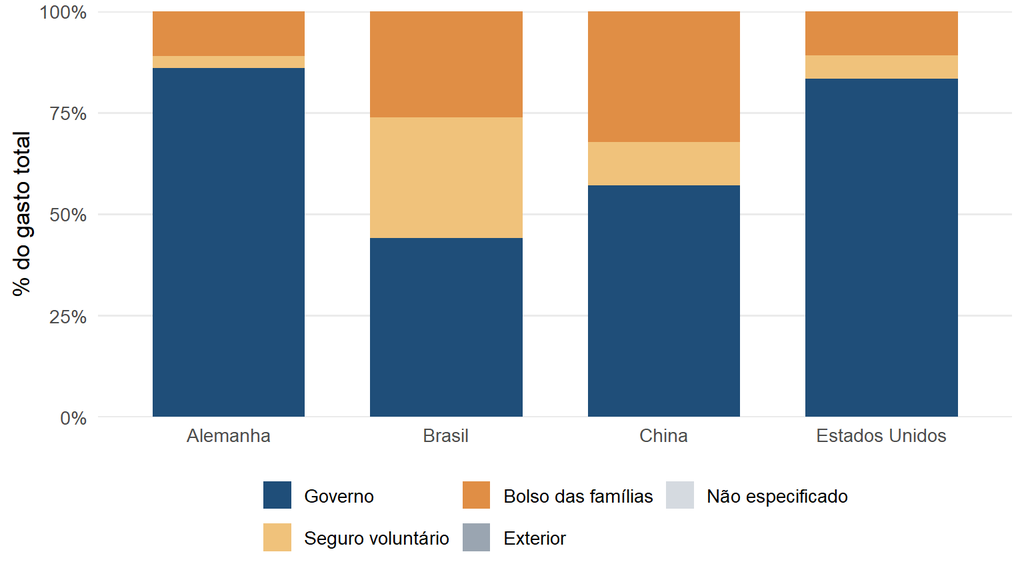

Figura 4: Esquemas de financiamento em países selecionados, 2023 (% do gasto total). Fonte: elaboração própria, com dados da OMS (GHED).

## 3.3 O gasto direto das famílias

O pagamento direto das famílias é o indicador mais associado ao risco financeiro da doença (Xu et al., 2003). Em 2023, os países onde ele mais pesa são Armênia (80,5%), Bangladesh (79,3%) e Turcomenistão (77,4%). Em 32 dos 194 países com dados, mais da metade do gasto em saúde saiu diretamente do bolso das famílias. A mediana mundial caiu de 38,1% em 2000 para 27,5% em 2023, uma melhora geral na proteção financeira.

O Brasil seguiu o mesmo movimento, com queda de intensidade semelhante à da mediana: o gasto direto das famílias caiu de 36,6% em 2000 para 26,2% em 2023, valor ligeiramente inferior à mediana mundial de 27,5% (Figura 5). A distribuição é bastante dispersa, e o Brasil fica em posição intermediária.

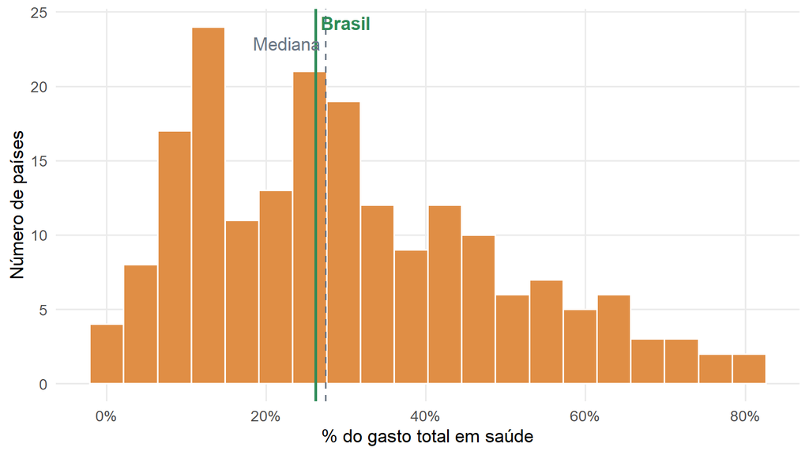

Figura 5: Distribuição da participação do gasto direto das famílias, 2023. A linha verde marca o Brasil e a tracejada, a mediana mundial. Fonte: elaboração própria, com dados da OMS (GHED).

## 3.4 Gasto total e forma de financiamento

Uma hipótese comum é que países que gastam mais em saúde dependem menos do pagamento direto das famílias. Para testá-la, calculou-se a correlação de Spearman entre o gasto total e a participação do gasto direto em 2023. O resultado foi de rho = 0,00 (p = 0,966), ou seja, **não há evidência de associação** (Figura 6). A nuvem de pontos não mostra tendência: países pequenos e grandes aparecem em todos os níveis de gasto direto.

A razão provável é que o gasto total depende muito do tamanho da população. Um país populoso gasta muito em valor absoluto mesmo com gasto per capita baixo, e isso mistura países de realidades distintas. Já a associação com a participação do governo é positiva, ainda que fraca: rho = 0,25 (p < 0,001). Países que gastam mais, em valor total, tendem a ter uma fatia pública um pouco maior. Uma análise per capita, que exigiria dados de população externos à base, seria o caminho natural para investigar melhor essa relação.

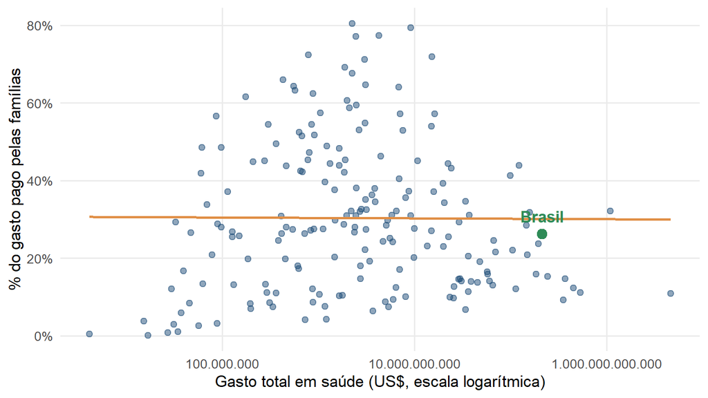

Figura 6: Gasto total e participação do gasto direto das famílias, 2023 (escala logarítmica no eixo horizontal). Fonte: elaboração própria, com dados da OMS (GHED).

## 3.5 Em que o dinheiro é gasto

A tabela de finalidade permite ver o tipo de serviço financiado. Em 2019, ano com 122 países com dados, a atenção curativa foi a maior categoria, com mediana de 54,7% do gasto, enquanto os serviços preventivos ficaram em 4,2% (Figura 7). No Brasil, a atenção curativa respondeu por 50,2% e a prevenção por 4,3%, valores próximos aos da mediana mundial. Chama atenção o peso dos bens médicos, de 20,4% do gasto no Brasil em 2019, o mais alto entre os quatro países da figura. Como esta tabela cobre poucos países e anos, a comparação deve ser lida com cautela.

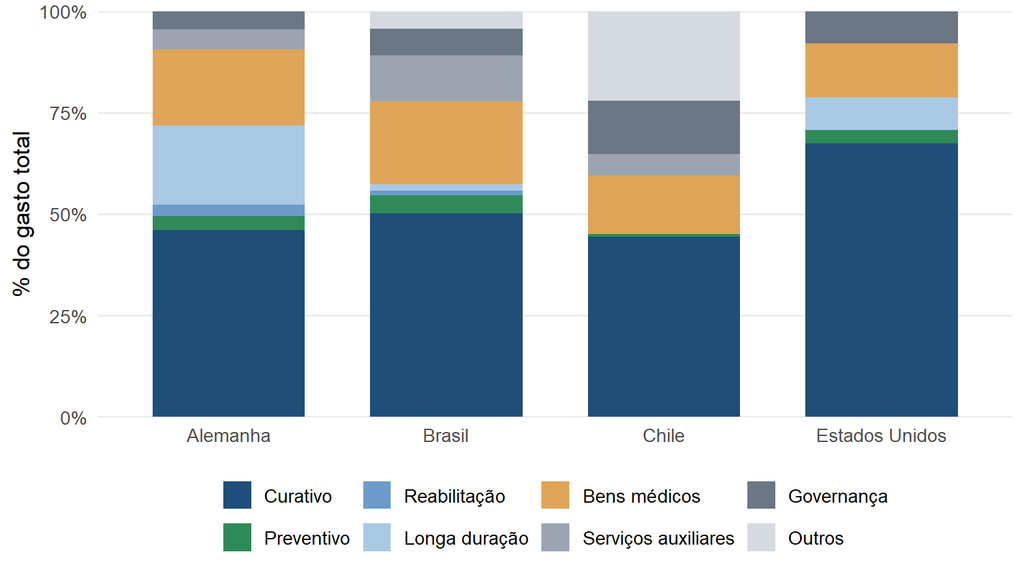

Figura 7: Finalidade do gasto em saúde em países selecionados, 2019 (% do gasto total). Fonte: elaboração própria, com dados da OMS (GHED).

## 3.6 O efeito da pandemia de COVID-19

Entre 2019 e 2020, o gasto em saúde aumentou na maioria dos países. A mediana da variação foi de 5,0%, e 71% dos 194 países com dados tiveram aumento. O teste de Wilcoxon pareado indica que a mudança é estatisticamente significativa (p < 0,001). Em 2021, a variação mediana em relação a 2019 chegou a 11,9%, o que sugere que o aumento se manteve e até cresceu no segundo ano da pandemia.

A Tabela 2 resume as duas comparações. Os extremos mostram a heterogeneidade do período: as variações foram de -55,0% (Lesoto) a 60,4% (República do Congo). O Brasil ficou fora da tendência predominante: seu gasto variou -3,2% em 2020, uma queda leve, e voltou a crescer em 2021, com 1,6% sobre 2019, bem abaixo da mediana mundial (Figura 8). Os dados não permitem apontar as causas dessas diferenças; fatores como a variação cambial, a queda de procedimentos eletivos e o gasto emergencial com a pandemia são hipóteses a investigar.

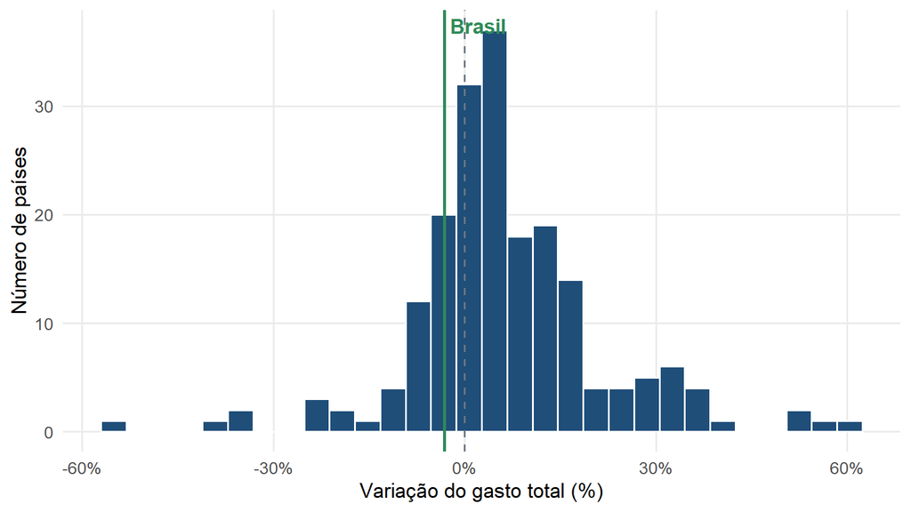

Figura 8: Variação do gasto total em saúde entre 2019 e 2020 (%). A linha verde marca o Brasil. Fonte: elaboração própria, com dados da OMS (GHED).

Tabela 2: Variação do gasto total em saúde em relação a 2019. Fonte: elaboração própria, com dados da OMS (GHED).

| Período | Países | Mediana (%) | 1º quartil (%) | 3º quartil (%) | Países com aumento (%) | Brasil (%) |
| --- | --- | --- | --- | --- | --- | --- |
| 2019 a 2020 | 194 | 5,0 | -1,1 | 13,4 | 71 | -3,2 |
| 2019 a 2021 | 194 | 11,9 | 6,2 | 22,6 | 83 | 1,6 |

## 3.7 O Brasil em perspectiva

A Tabela 1 mostra a posição do Brasil em relação à distribuição mundial em 2023. O país gasta cerca de US$ 213 bilhões por ano, o que o coloca entre os dez maiores gastadores, mas com um perfil de financiamento diferente do típico: a participação pública é bem inferior à mediana mundial, e a privada é bem superior, enquanto o pagamento direto das famílias está próximo da mediana.

# 4 Limitações

Os resultados devem ser lidos com algumas ressalvas. Primeiro, a base não traz população, renda ou região dos países, de modo que as comparações usam o gasto total e não o gasto per capita, o que dificulta comparar países de tamanhos diferentes. Segundo, os valores em dólares constantes de 2023 corrigem a inflação, mas não as diferenças de preços entre países. Terceiro, nem todos os países têm dados em todos os anos, e Cuba não tem valores em dólares. Quarto, a tabela de finalidade cobre menos países e anos, e o número de países com dados cai depois de 2019, o que limita comparações no tempo. Por fim, os percentuais ausentes foram tratados como zero, uma decisão razoável dado que as partes somam cerca de 100%, mas que pode ocultar casos de dado não informado. Os testes aplicados descrevem associações e diferenças, e não permitem afirmar relações de causa e efeito.

# 5 Conclusão

O gasto mundial em saúde mais que dobrou entre 2000 e 2023 e é muito concentrado: poucos países respondem por cerca de dois terços do total, e os Estados Unidos sozinhos por mais de 40%. Em termos de financiamento, a mediana mundial indica um aumento da participação pública e uma queda do pagamento direto das famílias, o que sugere melhora na proteção financeira em escala global. Por outro lado, o gasto total não se associou ao peso do pagamento direto, o que indica que o tamanho do gasto, sem ajuste pela população, não explica a forma de financiamento.

A pandemia de COVID-19 deixou marca clara: o gasto cresceu na maioria dos países entre 2019 e 2020, de forma estatisticamente significativa. Já o Brasil teve um comportamento diferente, com queda leve em 2020. O país ocupa a oitava posição no gasto total e tem um financiamento em que o setor privado, especialmente os planos de saúde, tem peso maior do que o da mediana mundial, apesar da existência de um sistema público universal.

Como próximos passos, recomenda-se incorporar dados de população e renda para análises per capita, e examinar com mais detalhe a trajetória do gasto privado brasileiro.

# Declaração de uso de inteligência artificial

Foi utilizada a ferramenta de inteligência artificial Claude (Anthropic) como apoio em diversas etapas deste trabalho: na apresentação, orientação e explicação de conceitos e de procedimentos desconhecidos de configuração (R, GitHub e shinyapps.io), tal como a revisão dos códigos do relatório e aplicativo e tradução e concatenação dos materiais utilizados para a confecção do projeto.

# Referências

BRASIL. **Constituição da República Federativa do Brasil de 1988**. Brasília, DF: Senado Federal, 1988.

ORGANIZAÇÃO MUNDIAL DA SAÚDE. **Relatório Mundial da Saúde 2010: financiamento dos sistemas de saúde, o caminho para a cobertura universal**. Genebra: Organização Mundial da Saúde, 2010.

ORGANIZAÇÃO MUNDIAL DA SAÚDE. **Global Health Expenditure Database (GHED)**., 2025. Disponível em: <https://apps.who.int/nha/database>

PAIM, Jairnilson *et al.* The Brazilian health system: history, advances, and challenges. **The Lancet**, v. 377, n. 9779, p. 1778–1797, 2011.

R CORE TEAM. **[R: A language and environment for statistical computing](https://www.R-project.org/)**. Viena, Áustria: R Foundation for Statistical Computing, 2025.

R4DS ONLINE LEARNING COMMUNITY. **TidyTuesday: A weekly data project aimed at the R ecosystem**., 2026. Disponível em: <https://github.com/rfordatascience/tidytuesday>

SPEARMAN, Charles. [The proof and measurement of association between two things](https://doi.org/10.2307/1412159). **The American Journal of Psychology**, v. 15, n. 1, p. 72–101, 1904.

WICKHAM, Hadley *et al.* [Welcome to the tidyverse](https://doi.org/10.21105/joss.01686). **Journal of Open Source Software**, v. 4, n. 43, p. 1686, 2019.

WILCOXON, Frank. [Individual comparisons by ranking methods](https://doi.org/10.2307/3001968). **Biometrics Bulletin**, v. 1, n. 6, p. 80–83, 1945.

XIE, Yihui; ALLAIRE, J. J.; GROLEMUND, Garrett. **[R Markdown: The Definitive Guide](https://bookdown.org/yihui/rmarkdown)**. Boca Raton, Flórida: Chapman; Hall/CRC, 2018.

XU, Ke *et al.* Household catastrophic health expenditure: a multicountry analysis. **The Lancet**, v. 362, n. 9378, p. 111–117, 2003.